# NoteBook Imputación - ML Imagenes

##### Realizado por:

- **Nestor Jardany Serrano Rojas**, [GitHub](https://github.com/jardanys/Anomalia_Imputacion_Imagenes)

## IMPUTACIÖN

### Visualización vector enmascarado

Gráfica para visualizar vector enmascarado, con datos faltantes.

```r
plotcdm <- function(v, m){
  ina <- which(m==0)
  w <- v
  w[ina] <- NA
  x <- matrix(w,64,64)
  image(1:65,1:65,t(apply(x,2,rev)),asp=1,xaxt="n",yaxt="n",
        col=grey((0:255)/255),ann=FALSE,bty="n")
}
plotcd <- function(v){
  x <- matrix(v,64,64)
  image(1:65,1:65,t(apply(x,2,rev)),asp=1,xaxt="n",yaxt="n",
        col=grey((0:255)/255),ann=FALSE,bty="n")
}
```

### Función de generación de máscaras

Esta función recibe como parámetros el número de filas, número de columnas y la probabildiad de omitir un dato, se realiza para obtener un porcentaje de datos faltantes.

- 0 en la máscara indica que el dato se omite
- 1 en la máscara indica que el dato se conserva

```r
get.mask <- function(d1,# Número de filas
                     d2,# Número de columnas
                     p# probabilidad de omitir un dato
){
  return(matrix(sample(c(0,1),d1*d2,prob=c(p,1-p),replace=TRUE), d1, d2))
}
```

Reconstrucción de un vector a partir de una base completa conocida y generación de la base

```r
pc <- prcomp(gatos.train)
matriz.proyec <- pc$rotation
```

### Máscara

Verificar experimentalmente para qué rango de p el resultado del algoritmo es “bueno”.

```r
mask.gatos.test <- get.mask(nrow(gatos.test),
                            ncol(gatos.test),
                            p=0.9)
```

Parámetro clave: cuántos vectores propios tomar.

- ¿Cuál es el dominio de este parámetro? El dominio es entre 1 y el número de componentes en este caso 90
- ¿Qué pasa si este parámetro cambia? Se utilizan un conjunto n de parámetros

```r
n <- 90
matriz.proyec.n <- matriz.proyec[, 1:n]
```

## Reconstrucción

### Reconstrución ara Gatos Entrenamiento

A partir de unos datos faltantes definidos, con los datos de entrenamiento se reconstruye la imagen utiloizando todos los componentes.

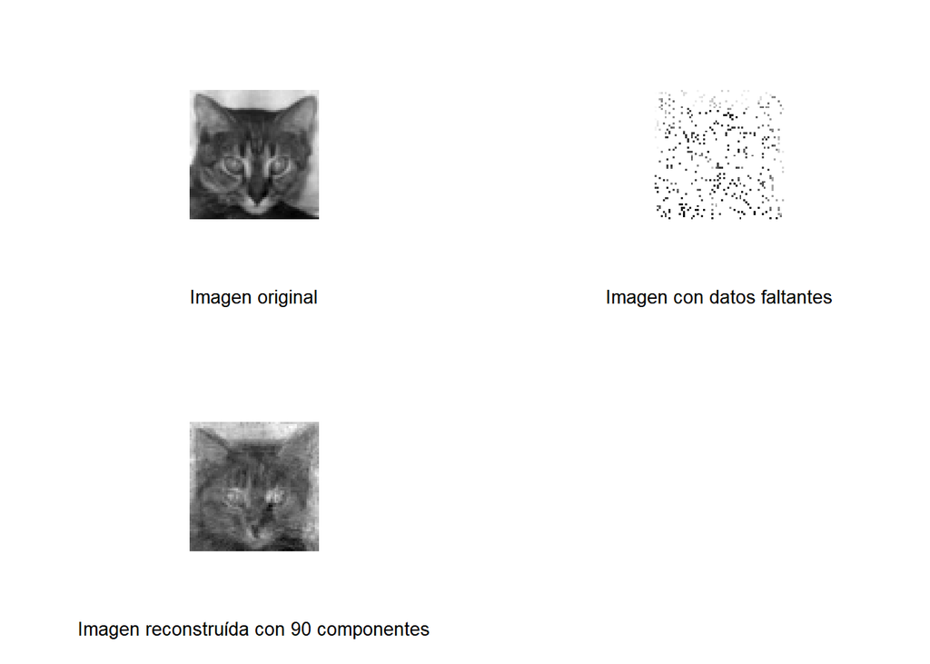

```r
gatos.test.filled <- 0*gatos.test
for(igs in 1:nrow(gatos.test)){ # Para cada gato de prueba
  gato <- gatos.test[igs, , drop=FALSE]
  mask <- mask.gatos.test[igs, , drop=FALSE]
  i.mask <- (which(mask==1))
  g.mask <- gato[1, i.mask, drop=FALSE]
  u.mask <- matriz.proyec.n[i.mask, ]
  M <- t(u.mask)%*%u.mask
  f <- t(g.mask %*% u.mask)
  a <- solve(M,f)

  gatos.test.filled[igs,] <- t(matriz.proyec.n %*% a)
}

i.gtest <- sample(1:nrow(gatos.test),1)

par(pty="s")
layout(matrix(c(1,2,3,4),2,2,byrow=TRUE))
plotcd(gatos.test[i.gtest,])
title(xlab="Imagen original")
plotcdm(gatos.test[i.gtest,], mask.gatos.test[i.gtest,])
title(xlab="Imagen con datos faltantes")
plotcd(gatos.test.filled[i.gtest,])
title(xlab=paste("Imagen reconstruída con ", n, " componentes",sep=""))
```

### Residuos Gatos Entrenamiento

Se calculan los resifuos para la base de entrenamiento utilizando todos los componentes. Se observa un valor muy cercano a cero.

```r
gatos.train.proyec <- (gatos.train %*% matriz.proyec) %*% t(matriz.proyec)
gatos.train.resid <- gatos.train - gatos.train.proyec
mean(gatos.train.resid)
```

```
## [1] -0.000000000000004855285
```

### Reconstrucción para perros de entrenamiento

Se crea una máscara para Verificar experimentalmente qué rango de p el resultado del algoritmo es “bueno”.

```r
mask.perros.test <- get.mask(nrow(perros.test), ncol(perros.test), p=0.2)
```

Parámetro clave: - cuántos vectores propios tomar. - ¿Cuál es el dominio de este parámetro? - ¿Qué pasa si este parámetro cambia?

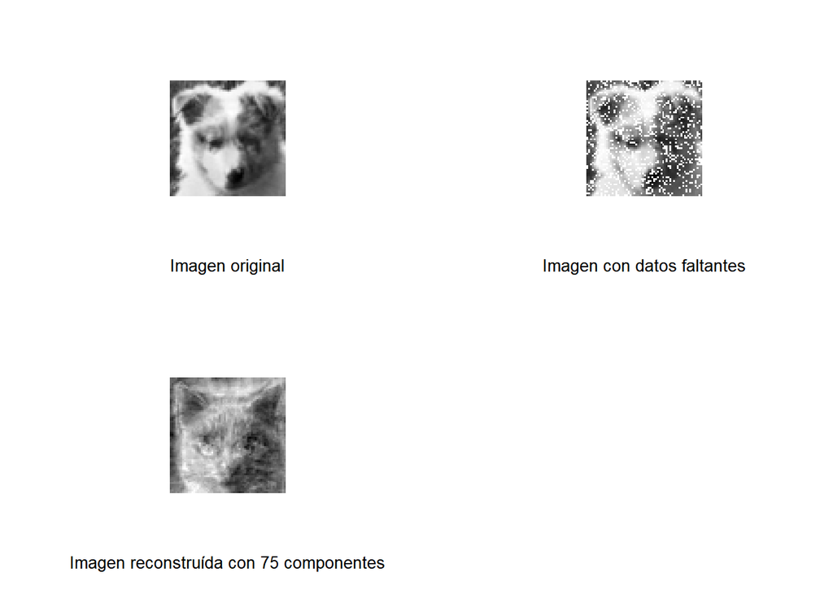

```r
n <- 75
matriz.proyec.n <- matriz.proyec[, 1:n]

### Reconstrucción
perros.test.filled <- 0*perros.test
for(igs in 1:nrow(perros.test)){ # Para cada gato de prueba
  perro <- perros.test[igs, , drop=FALSE]
  mask <- mask.perros.test[igs, , drop=FALSE]
  i.mask <- (which(mask==1))
  p.mask <- perro[1, i.mask, drop=FALSE]
  u.mask <- matriz.proyec.n[i.mask, ]
  M <- t(u.mask)%*%u.mask
  f <- t(p.mask %*% u.mask)
  a <- solve(M,f)

  perros.test.filled[igs,] <- t(matriz.proyec.n %*% a)
}


i.gtest <- sample(1:nrow(perros.test),1)
par(pty="s")
layout(matrix(c(1,2,3,4),2,2,byrow=TRUE))
plotcd(perros.test[i.gtest,])
title(xlab="Imagen original")
plotcdm(perros.test[i.gtest,], mask.perros.test[i.gtest,])
title(xlab="Imagen con datos faltantes")
plotcd(perros.test.filled[i.gtest,])
title(xlab=paste("Imagen reconstruída con ", n, " componentes",sep=""))
```

## Escoger el mejor modelo

Se realiza un loop para determinar la mejor opción de modelo dados los siguientes parámetros:

- Porcentaje de vacios.
- Número de Componentes
- Menor media de los residuos

```r
p <- 0
n <- 0
mean_resid <- 0

pp <- c(0.1, 0.2, 0.3, 0.4, 0.5, 0.6, 0.7, 0.8, 0.9)
nn <- c(10, 20, 30, 40, 50, 60, 70, 80, 90)

datos <- data.frame(p, n, mean_resid)

for(pe in pp){
  mask.gatos.test <- get.mask(nrow(gatos.test), ncol(gatos.test), p=pe)
  for(ne in nn){
    n <- ne
    matriz.proyec.n <- matriz.proyec[, 1:n]
    gatos.test.filled <- 0*gatos.test
      for(igs in 1:nrow(gatos.test)){ # Para cada gato de prueba
        gato <- gatos.test[igs, , drop=FALSE]
        mask <- mask.gatos.test[igs, , drop=FALSE]
        i.mask <- (which(mask==1))
        g.mask <- gato[1, i.mask, drop=FALSE]
        u.mask <- matriz.proyec.n[i.mask, ]
        M <- t(u.mask)%*%u.mask
        f <- t(g.mask %*% u.mask)
        a <- solve(M,f)
        gatos.test.filled[igs,] <- t(matriz.proyec.n %*% a)
      }
    i.gtest <- sample(1:nrow(gatos.test),1)
    par(pty="s")
    layout(matrix(c(1,2,3,4),2,2,byrow=TRUE))
    gatos.train.proyec <- (gatos.train %*% matriz.proyec.n) %*% t(matriz.proyec.n)
    gatos.train.resid <- gatos.train - gatos.train.proyec
    mean_resid <- mean(gatos.train.resid)
    z <- c(pe, ne, mean_resid)
    datos <- rbind(datos, z)
  }
}

datos <- datos[-1,]

kable(datos, "html") %>%
  kable_styling("striped", full_width = F, position = "center") %>%
  scroll_box(width = "850px", height = "300px")
```

|  | p | n | mean_resid |
| --- | --- | --- | --- |
| 2 | 0.1 | 10 | 0 |
| 3 | 0.1 | 20 | 0 |
| 4 | 0.1 | 30 | 0 |
| 5 | 0.1 | 40 | 0 |
| 6 | 0.1 | 50 | 0 |
| 7 | 0.1 | 60 | 0 |
| 8 | 0.1 | 70 | 0 |
| 9 | 0.1 | 80 | 0 |
| 10 | 0.1 | 90 | 0 |
| 11 | 0.2 | 10 | 0 |
| 12 | 0.2 | 20 | 0 |
| 13 | 0.2 | 30 | 0 |
| 14 | 0.2 | 40 | 0 |
| 15 | 0.2 | 50 | 0 |
| 16 | 0.2 | 60 | 0 |
| 17 | 0.2 | 70 | 0 |
| 18 | 0.2 | 80 | 0 |
| 19 | 0.2 | 90 | 0 |
| 20 | 0.3 | 10 | 0 |
| 21 | 0.3 | 20 | 0 |
| 22 | 0.3 | 30 | 0 |
| 23 | 0.3 | 40 | 0 |
| 24 | 0.3 | 50 | 0 |
| 25 | 0.3 | 60 | 0 |
| 26 | 0.3 | 70 | 0 |
| 27 | 0.3 | 80 | 0 |
| 28 | 0.3 | 90 | 0 |
| 29 | 0.4 | 10 | 0 |
| 30 | 0.4 | 20 | 0 |
| 31 | 0.4 | 30 | 0 |

[output cut: 51 more lines]

EL modelo con menor residuo es:

```r
# Componentes con menor error
which.min(datos$mean_resid) + 1
```

```
## [1] 4
```

```r
# Parametros con los que se encontro menor error de prueba
datos[which.min(datos$mean_resid),]
```

```
##     p  n               mean_resid
## 4 0.1 30 -0.000000000000004864543
```

## IMPUTACCIÓN II

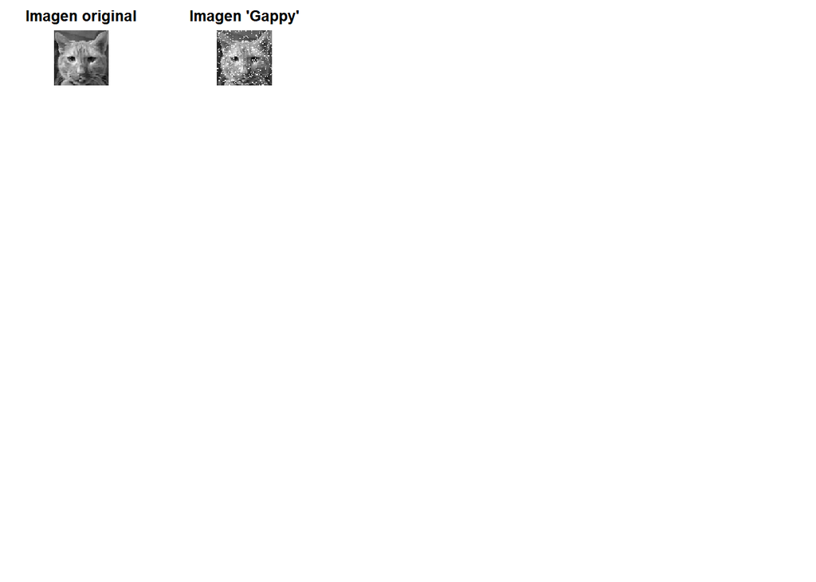

```r
mask.gatos.train <- get.mask(nrow(gatos.train),
                            ncol(gatos.train),
                            p=0.1)
i.gtrain <- sample(1:nrow(gatos.train),1)
par(pty="s",mar=rep(2,4))
layout(matrix(1:25,5,5,byrow=TRUE))
plotcd(gatos.train[i.gtrain,])
title(main="Imagen original")

gatos.train.masked <- gatos.train
i.gap <- which(mask.gatos.train==0)
gatos.train.masked[i.gap] <- NA
X <- gatos.train.masked

plotcd(gatos.train.masked[i.gtrain,])
title(main="Imagen 'Gappy'")
```

### Iteración 0: Llenar los faltantes con el promedio de cada pixel

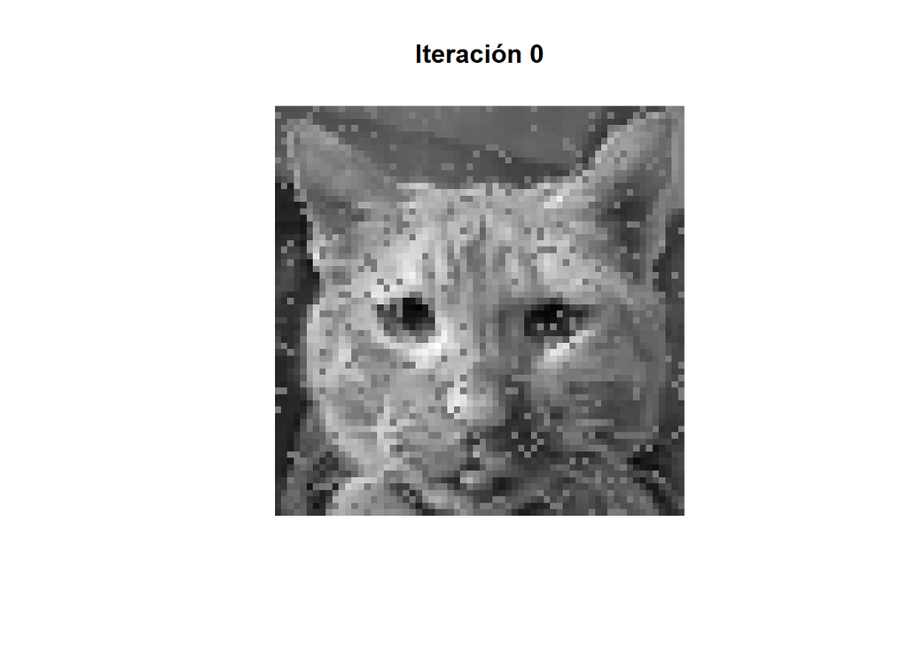

```r
X_0 <- matrix(colMeans(gatos.train.masked, na.rm = TRUE),
              nrow(gatos.train), ncol(gatos.train), byrow=TRUE)

X[i.gap] <- X_0[i.gap]
plotcd(X[i.gtrain,])
title(main="Iteración 0")
```

```r
err <- norm(gatos.train[i.gtrain,]-X[i.gtrain, ],"2")
print(paste("Iteración 0:", err, sep=" "))
```

```
## [1] "Iteración 0: 837.902615767094"
```

Parámetro clave: - cuántos vectores propios tomar. - ¿Cuál es el dominio de este parámetro? - ¿Qué pasa si este parámetro cambia?

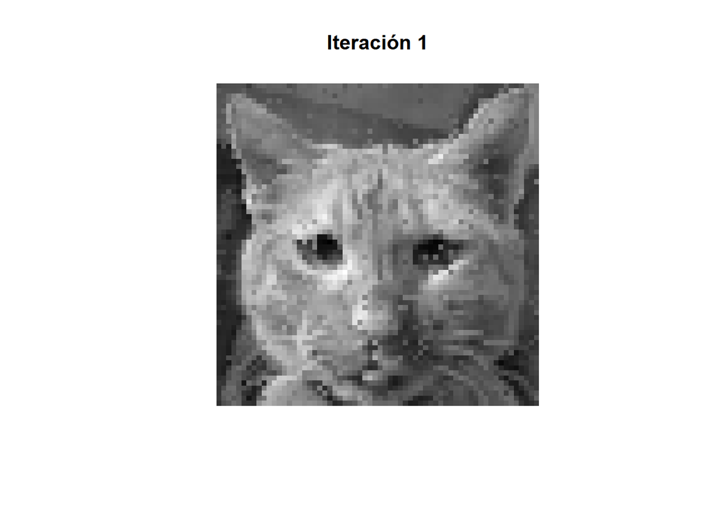

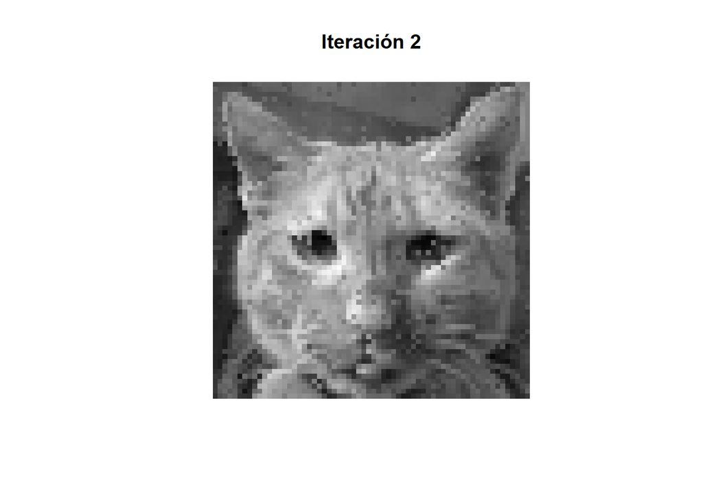

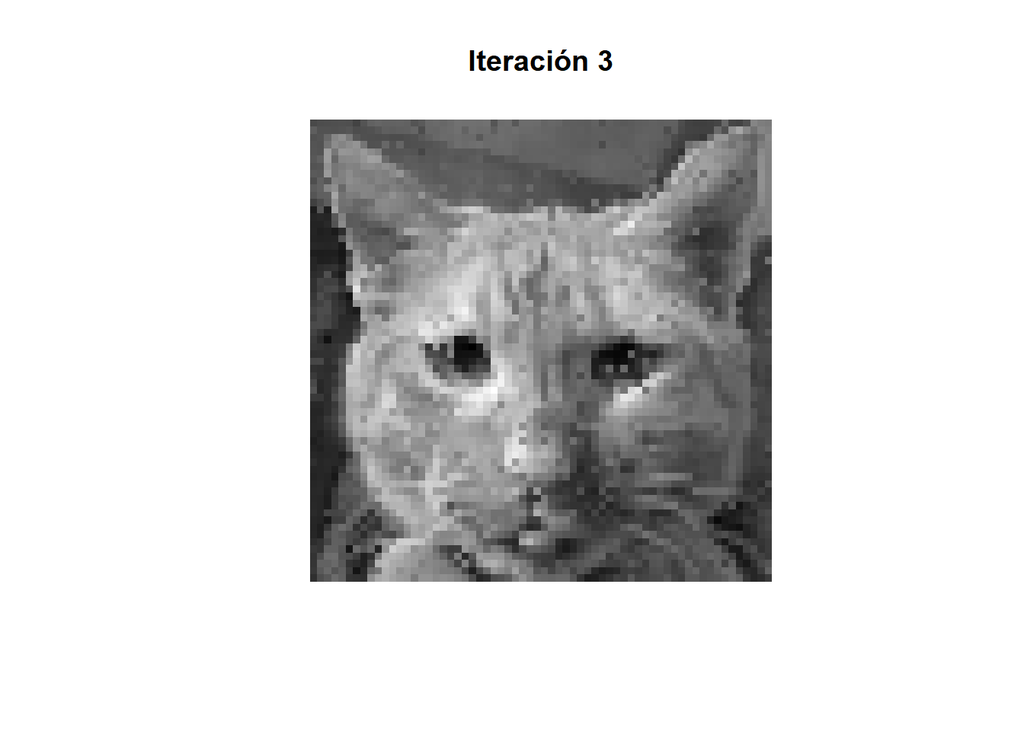

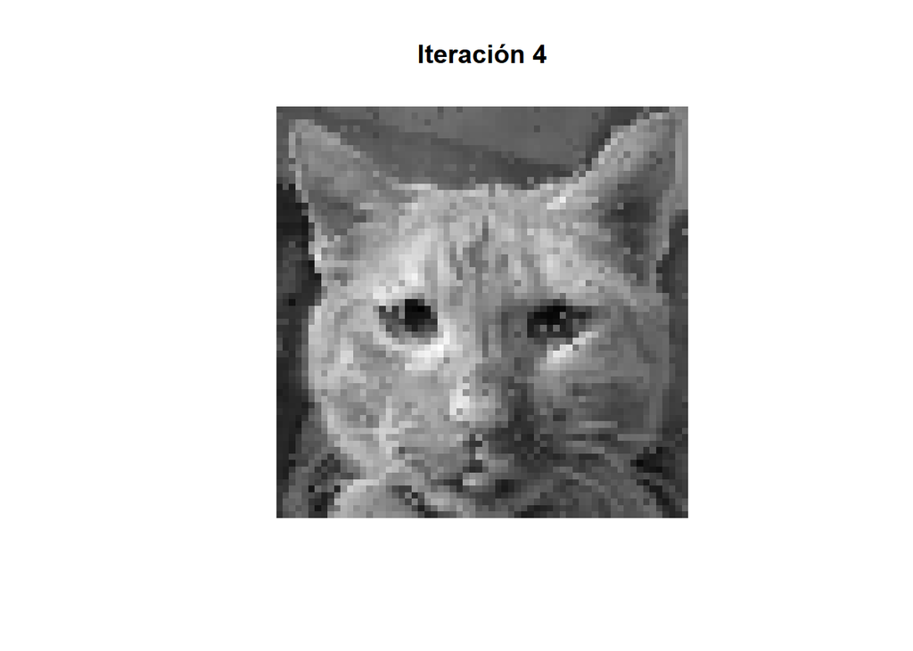

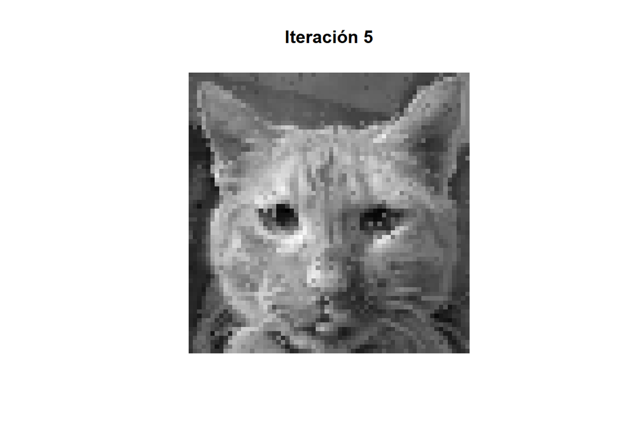

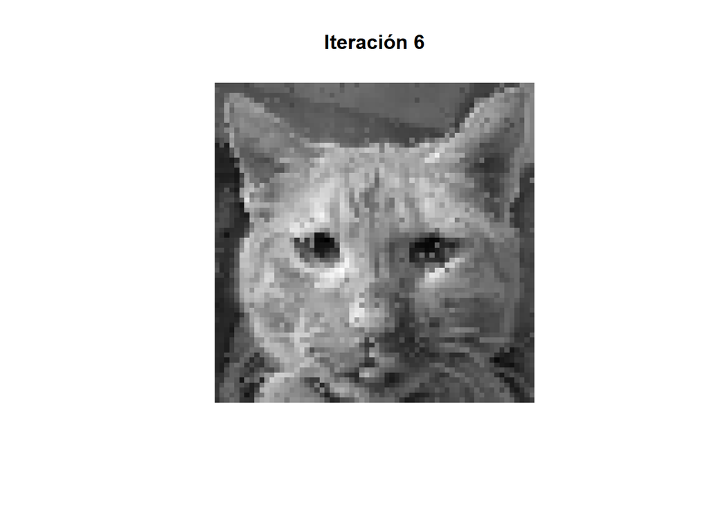

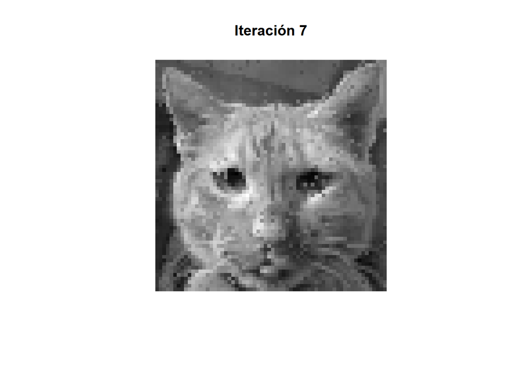

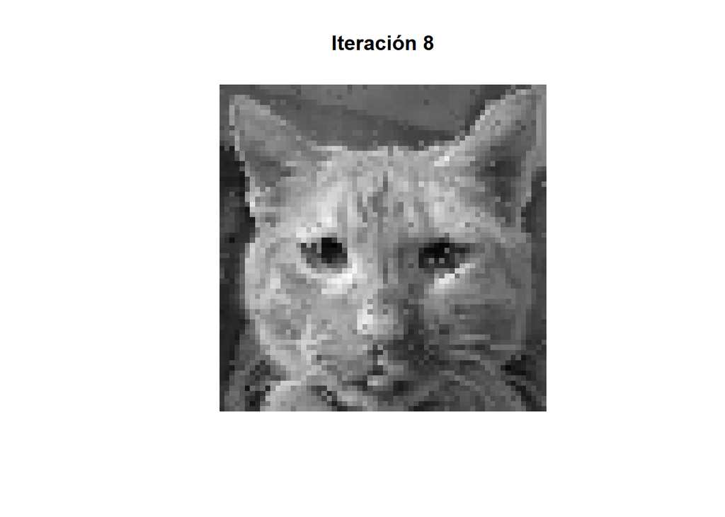

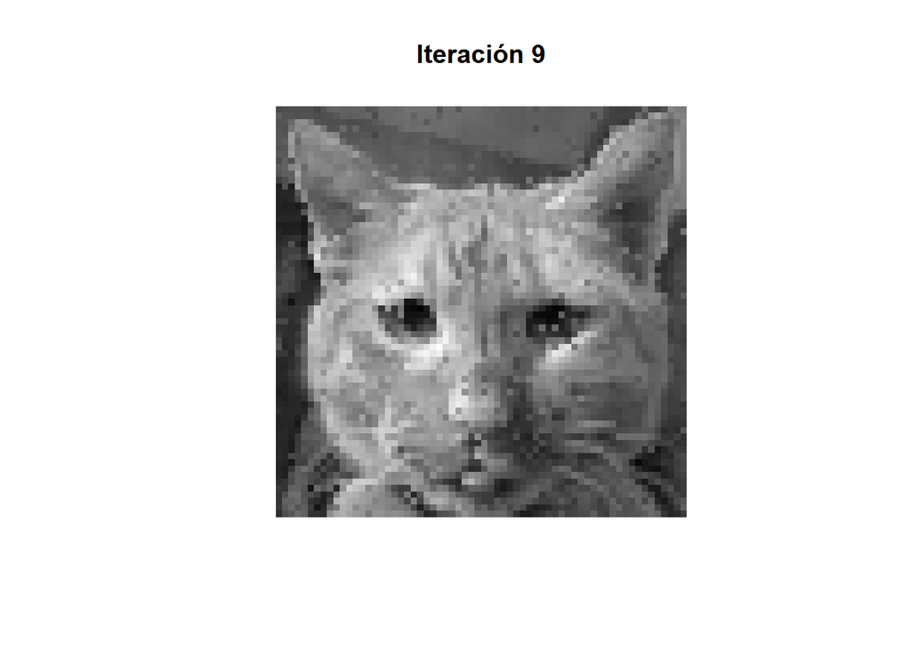

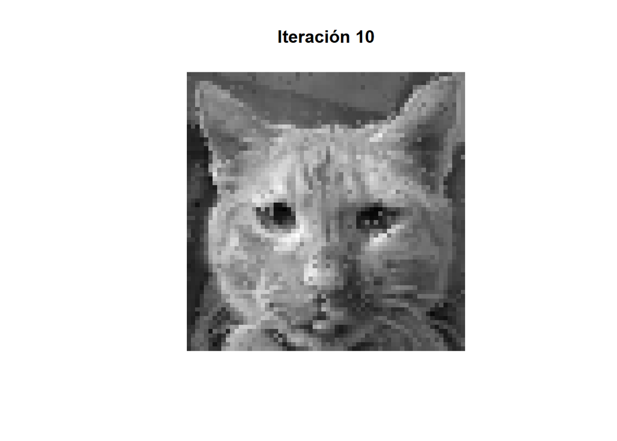

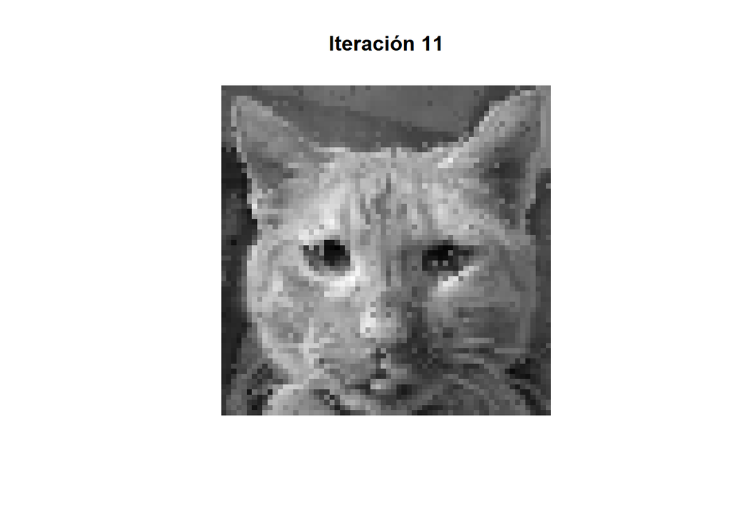

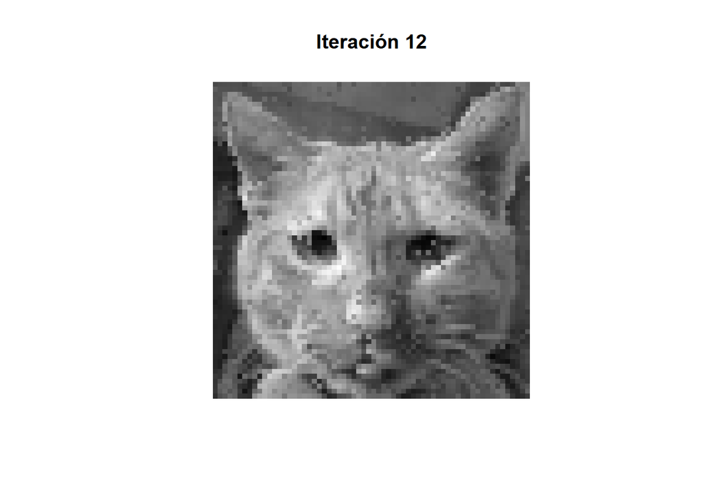

[8 more figures not shown]

```r
n <- 25
### Lazo: 20 iteraciones
X_i <- 0*gatos.train
for(iter in 1:20){
  ### Generación de la base
  pc <- prcomp(X)
  matriz.proyec.n <- pc$rotation[, 1:n]
  for(igs in 1:nrow(gatos.train)){
    gato <- X[igs, , drop=FALSE]
    mask <- mask.gatos.train[igs, , drop=FALSE]
    i.mask <- (which(mask==1))
    g.mask <- gato[1, i.mask, drop=FALSE]
    u.mask <- matriz.proyec.n[i.mask, ]
    M <- t(u.mask)%*%u.mask
    f <- t(g.mask %*% u.mask)
    a <- solve(M,f)
    X_i[igs, ] <- t(matriz.proyec.n %*% a)
  }
  X[i.gap] <- X_i[i.gap]
  plotcd(X[i.gtrain,])
  title(main=paste("Iteración", iter, sep=" "))
  err <- norm(gatos.train[i.gtrain,]-X[i.gtrain, ],"2")
}
```

2018-04 Nestor Jardany Serrano Rojas

Copyright © All rights reserved.